# final-notebook-copy

[Reddit](https://reddit.com) is a content aggregation website where members can submit links, text posts, images, and videos, which other members can then comment on and discuss. The posts "are organized by subject into user-created boards called 'subreddits', which cover a variety of topics including news, science, movies, video games, music, books, fitness, food, and image-sharing." ([Wikipedia](https://en.wikipedia.org/wiki/Reddit))

I will use Naive Bayes, $k$-Nearest Neighbors, and a Support-Vector Machine to model this problem.

#### Contents

1. Data Preparation
   - Data Gathering
   - Exploratory Data Analysis
2. Modeling
   - Naive Bayes
   - $k$-Nearest Neighbors
   - Support-Vector Machine

# Imports

```python
from sklearn.model_selection import train_test_split, GridSearchCV
from sklearn.feature_extraction.text import CountVectorizer, TfidfVectorizer
from sklearn.pipeline import Pipeline
from sklearn.naive_bayes import MultinomialNB
from sklearn.neighbors import KNeighborsClassifier
from sklearn.svm import SVC
from sklearn.metrics import confusion_matrix

from nltk import pos_tag
from nltk.corpus import wordnet
from nltk.corpus import stopwords
from nltk.tokenize import RegexpTokenizer
from nltk.stem.wordnet import WordNetLemmatizer

import requests
import time
import pandas as pd
import numpy as np
import matplotlib.pyplot as plt
import seaborn as sns

sns.set_style('dark')
```

# Data Gathering

First, I had to gather the data from Reddit's API. I scraped the top 1000 posts from each subreddit from Redditâ€™s API. I was only interested in the titles; the title of each post is the headline of the article to which the post is linked.

Once I had the posts, I put their titles in a list and made sure there were no duplicated titles. Since I used natural language processing for this problem, I did not want any words inaccurately over-represented in the data set.

#### Getting /r/TheOnion post titles

```python
headers = {'User-agent': 'Grace'}

# Web scraping Reddit's API for titles of 1000 hot posts from /r/TheOnion
onion_posts = []
after = None
for i in range(40):
    if after == None:
        params = {}
    else:
        params = {'after': after}
    url = 'https://www.reddit.com/r/theonion.json'
    res = requests.get(url, params=params, headers=headers)
    if res.status_code == 200:
        the_json = res.json()
        onion_posts.extend(the_json['data']['children'])
        after = the_json['data']['after']
    else:
        print(res.status_code)
        break
    time.sleep(2)

titles = []
for i in range(len(onion_posts)):
    titles.append(onion_posts[i]['data']['title'])

onion_titles = list((set(titles)))
len(onion_titles)
```

```python
# Web scraping Reddit's API for titles of 1000 hot posts from /r/News
news_posts = []
after = None
for i in range(40):
    if after == None:
        params = {}
    else:
        params = {'after': after}
    url = 'https://www.reddit.com/r/worldnews.json'
    res = requests.get(url, params=params, headers=headers)
    if res.status_code == 200:
        the_json = res.json()
        news_posts.extend(the_json['data']['children'])
        after = the_json['data']['after']
    else:
        print(res.status_code)
        break
    time.sleep(2)

titles = []
for i in range(len(news_posts)):
    titles.append(news_posts[i]['data']['title'])

news_titles = list(set(titles))
len(news_titles)
```

#### Turning the data into a dataframe

```python
# Creating a dataframe of titles and their respective class
onion = pd.DataFrame(onion_titles)
onion['is_onion'] = 1

news = pd.DataFrame(news_titles)
news['is_onion'] = 0

titles = news.append(onion, ignore_index=True)
titles.rename({0: 'title'}, axis=1, inplace=True)

# Saving dataframe to .csv
titles.to_csv('titles.csv', index=False)
```

# Exploratory Data Analysis

```python
df = pd.read_csv('./materials/titles.csv')
```

Let's take a preliminary look at the titles and classes in the data.

```python
# Looking at a few of the titles from each subreddit -- /r/TheOnion = 1, /r/News = 0
pd.options.display.max_colwidth = 300
df[:5].append(df[-11:-6])
```

|  | title | is_onion |
| --- | --- | --- |
| 0 | Trump threatens to close U.S.-Mexico border next week | 0 |
| 1 | German Government Refuses to Recognise Guaido’s Envoy as Ambassador | 0 |
| 2 | Netanyahu Takes Shot At Obama In Campaign Ad | 0 |
| 3 | MPs asked to vote on withdrawal agreement only | 0 |
| 4 | The shock of the nude: Brazil's stark new form of political protest | 0 |
| 1572 | Report: It Pretty Incredible That Americans Entrusted With Driving Cars | 1 |
| 1573 | Self-Conscious Puppet Has No Idea What To Do With Hands | 1 |
| 1574 | 5 Tokyo Buildings Godzilla Spared Because He Was Considering Having His Bar Mitzvah There | 1 |
| 1575 | Nation’s Flag Nerds Anxiously Watching D.C. Statehood Push | 1 |
| 1576 | ‘This One Means The Least Of All,’ Says Tom Brady Accepting Super Bowl Trophy | 1 |

```python
# Are there any null values?
df.isnull().sum()
```

```
title       0
is_onion    0
dtype: int64
```

```python
# Are classes balanced?
df['is_onion'].value_counts(normalize=True)
```

```
1    0.599495
0    0.400505
Name: is_onion, dtype: float64
```

There are no null values in this dataset. The classes are relatively balanced, with ~60% of the data from /r/TheOnion and ~40% from /r/News.

### Preprocessing the Data

First, I need to process the titles into tokens and vectorize them so that I can perform exploratory analysis and begin modeling.

This will take two steps:

1. Create a tokenizing function to break down each title into tokens.
   - Convert each word to a token that only includes alphabetical elements (i.e. no numbers or special characters)
   - Remove English stop words from the tokens list.
   - Define a function that transforms Penn Treebank part-of-speech tags into WordNet part-of-speech tags.
   - Use that function to map each token to its lemma (canonical, dictionary form of the word).
   - Return the final list of lemmatized tokens.
1. Use CountVectorizer to transform every word into a count of its frequency across documents.

```python
def get_wordnet_pos(treebank_tag):
    if treebank_tag.startswith('J'):
        return wordnet.ADJ
    elif treebank_tag.startswith('V'):
        return wordnet.VERB
    elif treebank_tag.startswith('N'):
        return wordnet.NOUN
    elif treebank_tag.startswith('R'):
        return wordnet.ADV
    else:
        return None

def token_func(document):
    tokenizer = RegexpTokenizer('[a-zA-Z]+')
    lemmatizer = WordNetLemmatizer()
    tokens = tokenizer.tokenize(document.lower())
    words = [w for w in tokens if w not in stopwords.words('english')]
    tagged = pos_tag(words)
    lemmas = []
    for word, tag in tagged:
        wntag = get_wordnet_pos(tag)
        if wntag is None:
            lemma = lemmatizer.lemmatize(word)
            lemmas.append(lemma)
        else:
            lemma = lemmatizer.lemmatize(word, pos=wntag)
            lemmas.append(lemma)
    return lemmas
```

```python
cvec = CountVectorizer(tokenizer=token_func)

features = cvec.fit_transform(df['title'])

features_df = pd.DataFrame(features.todense(), columns=cvec.get_feature_names()).join(df['is_onion'])
```

```python
# One of the most common tokens, 'u', maps to 'u.s.' so I will change it to reflect that
features_df = features_df.rename(columns={'u': 'u.s.'})
```

```python
# What the transformed data look like
features_df.head()
```

|  | abandon | abandoned | abc | abdel | abdicate | abduct | ability | able | abomination | aboriginal | ... | zebra | zeland | zendaya | zero | zion | zombie | zoo | zookeeper | zuckerberg | is_onion |
| --- | --- | --- | --- | --- | --- | --- | --- | --- | --- | --- | --- | --- | --- | --- | --- | --- | --- | --- | --- | --- | --- |
| 0 | 0 | 0 | 0 | 0 | 0 | 0 | 0 | 0 | 0 | 0 | ... | 0 | 0 | 0 | 0 | 0 | 0 | 0 | 0 | 0 | 0 |
| 1 | 0 | 0 | 0 | 0 | 0 | 0 | 0 | 0 | 0 | 0 | ... | 0 | 0 | 0 | 0 | 0 | 0 | 0 | 0 | 0 | 0 |
| 2 | 0 | 0 | 0 | 0 | 0 | 0 | 0 | 0 | 0 | 0 | ... | 0 | 0 | 0 | 0 | 0 | 0 | 0 | 0 | 0 | 0 |
| 3 | 0 | 0 | 0 | 0 | 0 | 0 | 0 | 0 | 0 | 0 | ... | 0 | 0 | 0 | 0 | 0 | 0 | 0 | 0 | 0 | 0 |
| 4 | 0 | 0 | 0 | 0 | 0 | 0 | 0 | 0 | 0 | 0 | ... | 0 | 0 | 0 | 0 | 0 | 0 | 0 | 0 | 0 | 0 |

5 rows Ã— 5056 columns

```python
# How many unique words do we have in this entire dataset?
len(cvec.get_feature_names())
```

```
5055
```

```python
# In the titles from /r/TheOnion, what are the 10 most frequently seen words?
features_df[features_df['is_onion'] == 1].sum().sort_values(ascending=False)[1:11]
```

```
new       74
man       66
say       60
get       53
trump     42
report    39
year      38
woman     37
time      34
make      33
dtype: int64
```

```python
# In the titles from /r/News, what are the 10 most frequently seen words?
features_df[features_df['is_onion'] == 0].sum().sort_values(ascending=False).head(10)
```

```
u.s.      85
say       75
brexit    58
trump     46
may       43
year      41
deal      34
new       32
report    32
eu        31
dtype: int64
```

In this first look, it appears that 'new' appears most frequently in titles from /r/TheOnion, while 'u.s.' appears the most in titles from /r/News. It looks like the words 'trump', 'report', and 'year' will not be very discerning, as both groups of titles see these words appear frequently.

```python
# How many words only appear once in /r/TheOnion titles?
(features_df.loc[features_df['is_onion'] == 1, :].sum() == 1).sum()
```

```
2357
```

```python
# How many words only appear once in /r/News titles?
(features_df.loc[features_df['is_onion'] == 0, :].sum() == 1).sum()
```

```
1416
```

```python
# How many words only appear once in the entire dataset?
(features_df.sum() == 1).sum()
```

```
2906
```

It appears that titles from /r/TheOnion contain more words that are unique within that subset of titles: there are 2,357 words that only appear once in the /r/TheOnion titles. By contrast, the /r/News titles have 1,416 such words.

Let's look at the most common words that are unique to each subreddit:

```python
# Creating the list of words that show up more than 10 times, for each subreddit
onion_words = list(features_df.loc[:, features_df.loc[features_df['is_onion'] == 1, :].sum() > 0].sum().index[:-1])
news_words = list(features_df.loc[:, features_df.loc[features_df['is_onion'] == 0, :].sum() > 0].sum().index)

# Iterating through the lists to create a Series of words unique to each subreddit + the word count
onion_unique = [word for word in onion_words if word not in news_words]
news_unique = [word for word in news_words if word not in onion_words]

onion_unique_df = (features_df[onion_unique].sum().sort_values(ascending=False)[:16])
news_unique_df  = (features_df[news_unique].sum().sort_values(ascending=False)[:16])

# Creating dataframe
pd.DataFrame({
    'onion_word': onion_unique_df.index,
    'onion_count': onion_unique_df.values,
    'news_word': news_unique_df.index,
    'news_count': news_unique_df.values
})
```

[output not shown]

### Visualization

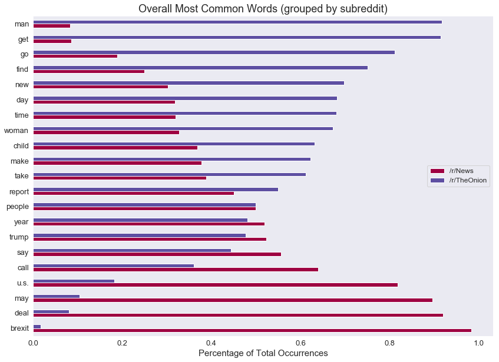

```python
# Making a list of the most common words in the entire dataset and turning it into a dataframe
most_common = list(features_df.sum().sort_values(ascending=False).index[1:22])
common_df = features_df[most_common].groupby(features_df['is_onion']).sum().T

# Creating new columns in order to configure the visualization
common_df['total'] = (common_df[1]+common_df[0])
common_df['onion_%'] = common_df[1]/common_df['total']
common_df['news_%'] = common_df[0]/common_df['total']
common_df = common_df.sort_values(by='onion_%')

# Plotting/formatting
ax = common_df[['news_%', 'onion_%']].plot(kind='barh', figsize=(14, 10), fontsize=13, colormap='Spectral')
ax.set_title('Overall Most Common Words (grouped by subreddit)', fontsize=18)
ax.legend(labels=['/r/News', '/r/TheOnion'], loc=7, fontsize='large')
ax.set_xlabel('Percentage of Total Occurrences', fontsize=15);
```

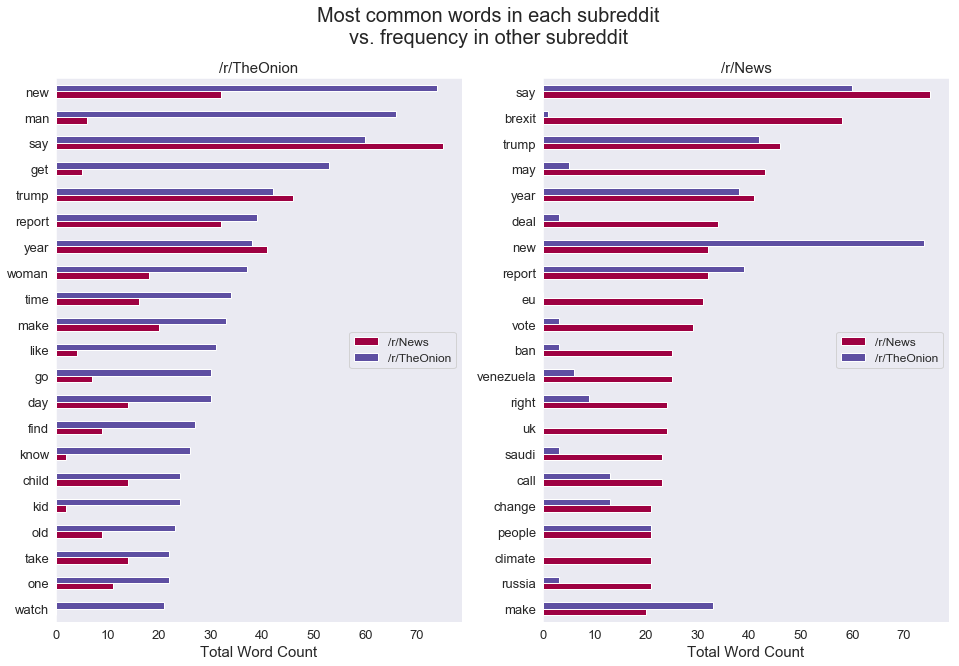

```python
# Making a list of the 21 most common words in each subreddit
onion_common = list(features_df.loc[features_df['is_onion'] == 1, :].sum()
                    .sort_values(ascending=False).index[1:22])
news_common = list(features_df.loc[features_df['is_onion'] == 0, :].sum()
                   .sort_values(ascending=False).index[1:22])

# Turning those lists into dataframes to plot
onion_common_df = features_df[onion_common].groupby(features_df['is_onion']).sum().T.sort_values(by=1)
news_common_df = features_df[news_common].groupby(features_df['is_onion']).sum().T.sort_values(by=0)

# Plotting/formatting
plt.figure().suptitle('Most common words in each subreddit\nvs. frequency in other subreddit', fontsize=20)

ax1 = plt.subplot(121)
onion_common_df.plot(kind='barh', figsize=(16, 10), fontsize=13, colormap='Spectral', ax=ax1)
ax1.set_title('/r/TheOnion', fontsize=15)
ax1.legend(labels=['/r/News', '/r/TheOnion'], loc=7, fontsize='large')
ax1.set_xlabel('Total Word Count', fontsize=15);

ax2 = plt.subplot(122)
news_common_df.plot(kind='barh', fontsize=13, colormap='Spectral', ax=ax2)
ax2.set_title('/r/News', fontsize=15)
ax2.legend(labels=['/r/News', '/r/TheOnion'], loc=7, fontsize='large')
ax2.set_xlabel('Total Word Count', fontsize=15);
```

# Modeling

### Naive Bayes

In this notebook, I will be modeling with `MultinomialNB`, which is a Naive Bayes classifier. Naive Bayes (as in Bayes' theorem) is a conditional probability model that assumes independence between the feature variables. While this is not a realistic assumption for a natural language model, the Naive Bayes classifier can make predictions with surprising accuracy.

#### Modeling Strategy

Before I can begin modeling, I need to turn my text data into numeric data using `CountVectorizer`. This transformer will create a matrix of values, where the columns represent every word that appears in the corpus, and the rows represent each document in the corpus. The values are gross counts of how many times a word appears in a document.

Both of these methods have hyperparameters that can be tuned to optimize model performance, so I will perform a grid search using a pipeline with `CountVectorizer` and `MultinomialNB` to find the best parameters for both in the context of one another.

The grid search will test 3 different `CountVectorizer` hyperparameters:

1. `max_features`: how many features to extract (chosen by highest total frequency)
2. `min_df`: the minimum number of documents in which a feature must appear
3. `max_df`: the maximum percentage of documents in which a feature can appear

and 2 different `MultinomialNB` hyperparameters:

1. `alpha`: the additive smoothing (Laplace/Lidstone smoothing) parameter to be used on each feature
2. `fit_prior`: whether the model will learn the prior probabilities of the classes

#### Grid Searching for Best Hyperparameters

```python
# Creating X and y
X = df['title']
y = df['is_onion']

# Train-test splitting (with stratification)
X_train, X_test, y_train, y_test = train_test_split(X, y, random_state=42, stratify=y)
```

```python
# Instantiating a pipeline
pipe = Pipeline([
    ('cvec', CountVectorizer(tokenizer=token_func)),
    ('mnb', MultinomialNB())
])

# Hyperparameters to search over
params = {
    'cvec__max_features': [None, 1000],
    'cvec__min_df': [1, 2],
    'cvec__max_df': [0.9, 1.0],
    'mnb__alpha': [1, 5],
    'mnb__fit_prior': [True, False]
}

# Fitting the grid search
grid = GridSearchCV(pipe, params, cv=3)
grid.fit(X_train, y_train);
```

```python
# The best accuracy score the grid search achieved through cross-validation
grid.best_score_
```

```
0.8407750631844987
```

```python
# Which parameters did the grid search choose?
grid.best_params_
```

```
{'cvec__max_df': 0.9,
 'cvec__max_features': None,
 'cvec__min_df': 1,
 'mnb__alpha': 1,
 'mnb__fit_prior': True}
```

For `CountVectorizer`, the grid search decided:

- `max_features` should be None
  - I will have to investigate how many features are kept in the model when there is no maximum. I do not want more features than I have rows in `X_train` (to prevent collinearity), so I may have to set the `max_features` anyway, regardless of this grid search result.
- `min_df` should be 1, effectively meaning there is no minimum document frequency
  - Again, I need to see how many features the model keeps, and may need to change `min_df` anyway.
- `max_df` should be 0.9, meaning a feature will not be included in the model if it appears in more than 90% of the documents
  - Since I eliminated stopwords from the tokens, there most likely will not be many (if any) words that show up in more than 90% of the titles.

For `MultinomialNB`, the grid search decided:

- `alpha` should be 1
  - This will add a smoothing parameter of 1 to each feature in the data
- `fit_prior` should be True
  - The model will learn the class prior probabilities

#### Transforming `X` Using Best Parameters

As I suspected, there are almost 3 times more features in `X_train` than there are rows when `max_features` is None. For the final transformation, I will set `max_features` equal to 1187 (the number of rows) so the number of features does not exceed the number of rows.

```python
cvec = CountVectorizer(tokenizer=token_func, max_features=1187, min_df=1, max_df=0.9)

cvec.fit(X_train)

X_train_c = pd.DataFrame(cvec.transform(X_train).todense(), columns=cvec.get_feature_names())
X_test_c  = pd.DataFrame(cvec.transform(X_test).todense(), columns=cvec.get_feature_names())
```

#### Running the Optimized Model

```python
# Instantiating and fitting the model
mnb = MultinomialNB(alpha=1, fit_prior=True)
mnb.fit(X_train_c, y_train)

# Storing predictions
y_pred = mnb.predict(X_test_c)
```

```python
# Accuracy score
mnb.score(X_test_c, y_test)
```

```
0.8661616161616161
```

```python
# Confusion Matrix + other metrics
tn, fp, fn, tp = confusion_matrix(y_test, y_pred).ravel()

print(f'True Positives: {tp}')
print(f'False Negatives: {fn}')
print(f'True Negatives: {tn}')
print(f'False Positives: {fp}\n')
print(f'Sensitivity: {tp/(tp+fn)}')
print(f'Specificity: {tn/(tn+fp)}')
```

```
True Positives: 201
False Negatives: 36
True Negatives: 142
False Positives: 17

Sensitivity: 0.8481012658227848
Specificity: 0.8930817610062893
```

#### Interpretation of Results

The grid search found that `max_features` should be None to optimize the model's performance. However, without a feature limit, the model had ~4000 features after vectorization. I had to reduce `max_features` to 1187, the number of rows in `X_train`, to reduce collinearity. To get the highest possible accuracy score from this model, I would need to gather more data so that the model could use more features to make predictions.

The baseline accuracy score for the data is the score I would get if I predicted the majority class for every data point. The majority class here, /r/TheOnion, holds around 60% of the data. If I were to predict that every document in the data belonged to /r/TheOnion, I would get an accuracy score of 60%. That is to say, if a model does not predict subreddit membership with greater than 60% accuracy, then it is not a very good model.

The model's accuracy score is 86.6%, which is well above the baseline score of 60%. This means that the model correctly predicted the class 86.6% of the time. The model has relatively high sensitivity at 84.8%, meaning that 84.8% of the posts that were actually from /r/TheOnion were correctly predicted to be from /r/TheOnion. The model has higher specificity, 89.3%, which means that 89.3% of posts that belong to /r/News were correctly predicted to be from /r/News.

In a real-world application, it is equally important to me that this model be able to correctly predict when a post is satirical **and** when it is real. The positive class in this case is does not hold more weight than the negative class, therefore I would rather the model be very accurate than very sensitive or very specific. This model, however, is all three, which means that for my purposes it is a great model.

## $k$-Nearest Neighbors

In this notebook, I will be modeling with `KNeighborsClassifier`, which uses the $k$-Nearest Neighbors algorithm (a non-parametric method) to predict the class of a data point. The algorithm looks at the class membership of the $k$ closest neighbors to the query point; whichever class is the most represented among the neighbors is the class that gets predicted for the query point.

[figure not shown]

[Image source](https://en.wikipedia.org/wiki/K-nearest_neighbors_algorithm#/media/File:KnnClassification.svg)

In the example above, the green dot is the query point. If $k$ is 3, then the majority class for the 3 nearest neighbors is 'red triangle', so the model will predict that class for the query point. If $k$ is 5, however, the majority class becomes 'blue square', so that is what the model will predict.

#### Modeling Strategy

Before I can begin modeling, I need to turn my text data into numeric data using `TfidfVectorizer`. This transformer will create a matrix of values, where the columns represent every word that appears in the corpus, and the rows represent each document in the corpus. The values are TFIDF statistics for each word in a document.

TFIDF stands for "term frequency-inverse document frequency" (**term frequency**: the number of times a word occurs in a document; **inverse document frequency**: an inverse function of the number of documents that contain the term). According to [Wikipedia](https://en.wikipedia.org/wiki/Tf%E2%80%93idf), "[t]he tfâ€“idf value increases proportionally to the number of times a word appears in the document and is offset by the number of documents in the corpus that contain the word, which helps to adjust for the fact that some words appear more frequently in general."

Both of these methods have hyperparameters that can be tuned to optimize model performance, so I will perform a grid search using a pipeline with `TfidfVectorizer` and `KNeighborsClassifier` to find the best parameters for both in the context of one another.

The grid search will test 3 different `TfidfVectorizer` hyperparameters:

1. `max_features`: how many features to extract (chosen by highest total frequency)
2. `min_df`: the minimum number of documents in which a feature must appear
3. `max_df`: the maximum percentage of documents in which a feature can appear

and 2 different `KNeighborsClassifier` hyperparameters:

1. `n_neighbors`: the $k$ in $k$-Nearest Neighbors -- how many neighbors to compare a data point to in order to decide its class
2. `weights`: the weight given to the neighbors (whether all are weighted equally or more weight is given to neighbors closer to the point in question)

#### Grid Searching for Best Hyperparameters

```python
# Creating X and y
X = df['title']
y = df['is_onion']

# Train-test splitting (with stratification)
X_train, X_test, y_train, y_test = train_test_split(X, y, random_state=42, stratify=y)
```

```python
# Instantiating a pipeline
pipe = Pipeline([
    ('tvec', TfidfVectorizer(tokenizer=token_func)),
    ('knn', KNeighborsClassifier())
])

# Hyperparameters to search over
params = {
    'tvec__max_features': [None, 1000],
    'tvec__min_df': [1, 2],
    'tvec__max_df': [0.9, 1.0],
    'knn__n_neighbors': [15, 25, 35],
    'knn__weights': ['uniform', 'distance']
}

# Fitting the grid search
grid = GridSearchCV(pipe, params, cv=3)
grid.fit(X_train, y_train);
```

```python
# The best accuracy score the grid search achieved through cross-validation
grid.best_score_
```

```
0.8037068239258636
```

```python
# Which parameters did the grid search choose?
grid.best_params_
```

```
{'knn__n_neighbors': 15,
 'knn__weights': 'distance',
 'tvec__max_df': 0.9,
 'tvec__max_features': None,
 'tvec__min_df': 1}
```

For `TfidfVectorizer`, the grid search decided:

- `max_features` should be None
  - I will have to investigate how many features are kept in the model when there is no maximum. I do not want many more features than I have rows in `X_train` (to prevent collinearity), so I may have to set the `max_features` anyway, regardless of this grid search result.
- `min_df` should be 1, effectively meaning there is no minimum document frequency
  - Again, I need to see how many features the model keeps, and may need to change `min_df` anyway.
- `max_df` should be 0.9, meaning a feature will not be included in the model if it appears in more than 90% of the documents
  - Since I eliminated stopwords from the tokens, there most likely will not be many (if any) words that show up in more than 90% of the titles.

For `KNeighborsClassifier`, the grid search decided:

- `n_neighbors` should be 15
  - The 15 neighbors closest to the query point will be considered. I believe that 15 neighbors is a number that results in a good bias-variance trade-off: it is small enough that the bias is relatively low, but not so small that the variance is extremely high.
- `weights` should be `distance`
  - The closer a neighbor is to the query point, the more influence that point will have over the class prediction. Neighbors that are farther away will have less influence.

#### Transforming `X` Using Best Parameters

As I suspected, there are almost 3 times more features in `X_train` than there are rows when `max_features` is None and `min_df` is only 1. After some adjustments, I found setting `max_features` to 2000 still results in a good score while not having too many more features than there are observations.

```python
tvec = TfidfVectorizer(tokenizer=token_func, max_features=2000, min_df=1, max_df=0.9)

tvec.fit(X_train)

X_train_t = pd.DataFrame(tvec.transform(X_train).todense(), columns=tvec.get_feature_names())
X_test_t  = pd.DataFrame(tvec.transform(X_test).todense(), columns=tvec.get_feature_names())
```

#### Running the Optimized Model

```python
# Instantiating and fitting the model
knn = KNeighborsClassifier(n_neighbors=15, weights='distance')
knn.fit(X_train_t, y_train)

# Storing predictions
y_pred = knn.predict(X_test_t)
```

```python
# Accuracy score
knn.score(X_test_t, y_test)
```

```
0.8156565656565656
```

```python
# Confusion Matrix + other metrics
tn, fp, fn, tp = confusion_matrix(y_test, y_pred).ravel()

print(f'True Positives: {tp}')
print(f'False Negatives: {fn}')
print(f'True Negatives: {tn}')
print(f'False Positives: {fp}\n')
print(f'Sensitivity: {tp/(tp+fn)}')
print(f'Specificity: {tn/(tn+fp)}')
```

```
True Positives: 224
False Negatives: 13
True Negatives: 99
False Positives: 60

Sensitivity: 0.9451476793248945
Specificity: 0.6226415094339622
```

#### Interpretation of Results

The baseline accuracy score for the data is the score I would get if I predicted the majority class for every data point. The majority class here, /r/TheOnion, holds around 60% of the data. If I were to predict that every document in the data belonged to /r/TheOnion, I would get an accuracy score of 60%. That is to say, if a model does not predict subreddit membership with greater than 60% accuracy, then it is not a very good model.

The model has very high sensitivity, meaning that almost all of the posts that were actually from /r/TheOnion were correctly predicted to be from /r/TheOnion. On the flip side, the model has much lower specificity, which means that only about 62% of posts that belong to /r/News were correctly predicted to be from /r/News. It seems that this model is content to predict the positive class almost every time.

In a real-world application, it is equally important to me that this model be able to correctly predict when a post is satirical **and** when it is real. The positive class in this case is does not hold more weight than the negative class, therefore I would rather the model be very accurate than very sensitive. For this reason, I do not believe $k$-Nearest Neighbors, at least not this iteration, is the best model for my purposes.

## Support-Vector Machine

In this notebook, I will be modeling with `SVC`, a support-vector machine for classification. Support-vector machines are representations of example data in space, **linearly separated** into classes by a clear gap that is as wide as possible. They map new example data to that space and predict a class based on which side of the gap a point falls. ([Source](https://en.wikipedia.org/wiki/Support-vector_machine))

If the classes are **not** linearly separable, the support-vector machine uses the *kernel trick*, a method that transforms the data and forces them into higher dimensions so the classes **are** linearly separable. The easiest way to understand this is with the following image:

[figure not shown]

[Image source](https://towardsdatascience.com/understanding-the-kernel-trick-e0bc6112ef78)

The figure on the left shows the data in two dimensions, not linearly separable. The figure on the right shows that same data, transformed into a three-dimensional space so that it can be separated by a hyperplane.

#### Modeling Strategy

Before I can begin modeling, I need to turn my text data into numeric data using `TfidfVectorizer`. This transformer will create a matrix of values, where the columns represent every word that appears in the corpus, and the rows represent each document in the corpus. The values are TFIDF statistics for each word in a document.

TFIDF stands for "term frequency-inverse document frequency" (**term frequency**: the number of times a word occurs in a document; **inverse document frequency**: an inverse function of the number of documents that contain the term). According to [Wikipedia](https://en.wikipedia.org/wiki/Tf%E2%80%93idf), "[t]he tfâ€“idf value increases proportionally to the number of times a word appears in the document and is offset by the number of documents in the corpus that contain the word, which helps to adjust for the fact that some words appear more frequently in general."

Both of these methods have hyperparameters that can be tuned to optimize model performance, so I will perform a grid search using a pipeline with `TfidfVectorizer` and `SVC` to find the best parameters for both in the context of one another.

The grid search will test 3 different `TfidfVectorizer` hyperparameters:

1. `max_features`: how many features to extract (chosen by highest total frequency)
2. `min_df`: the minimum number of documents in which a feature must appear
3. `max_df`: the maximum percentage of documents in which a feature can appear

and 2 different `SVC` hyperparameters:

1. `C`: controls how much the model regularizes the boundary that is fit between classes
2. `kernel`: how the kernel trick is performed (how the data is forced into higher dimensions)

```python
# Creating X and y
X = df['title']
y = df['is_onion']

# Train-test splitting (with stratification)
X_train, X_test, y_train, y_test = train_test_split(X, y, random_state=42, stratify=y)
```

```python
# Instantiating a pipeline
pipe = Pipeline([
    ('tvec', TfidfVectorizer(tokenizer=token_func)),
    ('svc', SVC(gamma='scale'))
])

# Hyperparameters to search over
params = {
    'tvec__max_features': [None, 1000],
    'tvec__min_df': [1, 2],
    'tvec__max_df': [0.9, 1.0],
    'svc__C': [10, 30],
    'svc__kernel': ['rbf', 'poly']
}

# Fitting the grid search
grid = GridSearchCV(pipe, params, cv=3)
grid.fit(X_train, y_train);
```

```python
# The best accuracy score the grid search found through cross-validation
grid.best_score_
```

```
0.8213984835720304
```

```python
# Which parameters did the grid search choose?
grid.best_params_
```

```
{'svc__C': 10,
 'svc__kernel': 'rbf',
 'tvec__max_df': 0.9,
 'tvec__max_features': None,
 'tvec__min_df': 2}
```

For `TfidfVectorizer`, the grid search decided:

- `max_features` should be None
  - I will have to investigate how many features are kept in the model when there is no maximum. I do not want more features than I have rows in `X_train` (to prevent collinearity), so I may have to set the `max_features` anyway, regardless of this grid search result.
- `min_df` should be 2
  - This means that a word must appear in at least 2 documents for it to be considered in the model.
- `max_df` should be 0.9, meaning a feature will not be included in the model if it appears in more than 90% of the documents
  - Since I eliminated stopwords from the tokens, there most likely will not be many (if any) words that show up in more than 90% of the titles.

For `SVC`, the grid search decided:

- `C` should be 10
  - A larger value of `C` means less regularization, and a more perfect classification of the data, which means there more chance of overfitting the model. However, I think 10 is low enough that the risk of overfitting is relatively small.
- `kernel` should be `rbf`, or 'radial basis kernel'
  - This kernel trick works well with circular or spherical data, and is the default kernel trick for `SVC` if none is specified.

#### Transforming `X` Using Best Parameters

As I suspected, not setting a value for `max_features` in the `TfidfVectorizer` kept more features in `X_train` than there are rows. For the final transformation, I will set `max_features` equal to 1187 (the number of rows) so the number of features does not exceed the number of rows.

```python
tvec = TfidfVectorizer(tokenizer=token_func, max_features=1187, min_df=2, max_df=0.9)

tvec.fit(X_train)

X_train_t = pd.DataFrame(tvec.transform(X_train).todense(), columns=tvec.get_feature_names())
X_test_t  = pd.DataFrame(tvec.transform(X_test).todense(), columns=tvec.get_feature_names())
```

#### Running the Optimized Model

```python
svc = SVC(C=10, kernel='rbf', gamma='scale')
svc.fit(X_train_t, y_train)

y_pred = svc.predict(X_test_t)
```

```python
# Accuracy score
svc.score(X_test_t, y_test)
```

```
0.8787878787878788
```

```python
# Confusion Matrix + other metrics
tn, fp, fn, tp = confusion_matrix(y_test, y_pred).ravel()

print(f'True Positives: {tp}')
print(f'False Negatives: {fn}')
print(f'True Negatives: {tn}')
print(f'False Positives: {fp}\n')
print(f'Sensitivity: {tp/(tp+fn)}')
print(f'Specificity: {tn/(tn+fp)}')
```

```
True Positives: 220
False Negatives: 17
True Negatives: 128
False Positives: 31

Sensitivity: 0.9282700421940928
Specificity: 0.8050314465408805
```

#### Interpretation of Results

The grid search found that `max_features` should be None to optimize the model's performance. However, without a feature limit, the model had more features than rows after vectorization. I had to reduce `max_features` to 1187, the number of rows in `X_train`, to reduce collinearity. To get the highest possible accuracy from this model, I would need to gather more data so that the model could use more features to make predictions.

The baseline accuracy score for the data is the score I would get if I predicted the majority class for every data point. The majority class here, /r/TheOnion, holds around 60% of the data. If I were to predict that every document in the data belonged to /r/TheOnion, I would get an accuracy score of 60%. That is to say, if a model does not predict subreddit membership with greater than 60% accuracy, then it is not a very good model.

The model's accuracy score is 87.9%, which is well above the baseline score of 60%. This means that the model correctly predicted the class 87.9% of the time. The model has very high sensitivity at 92.9%, meaning that 92.9% of the posts that were actually from /r/TheOnion were correctly predicted to be from /r/TheOnion. The model has lower specificity, 80.5%, which means that 80.5% of posts that belong to /r/News were correctly predicted to be from /r/News.

In a real-world application, it is equally important to me that this model be able to correctly predict when a post is satirical **and** when it is real. The positive class in this case is does not hold more weight than the negative class, therefore I would rather the model be very accurate than very sensitive or very specific. This model, however, is all three, which means that for my purposes it is a great model.

# Final Thoughts

Naive Bayes and SVM both had high accuracy, sensitivity, and specificity, while $k$-Nearest Neighbors had high accuracy and high sensitivity, but low specificity.

Although accuracy is more important to me in this case than sensitivity or specificity, $k$-Nearest Neighbors, at least not this iteration, is not the best model due to its low specificity compared to the other two models. Naive Bayes and SVM are both good models that I would use for this classification problem. To improve all three of these models, I would like to gather more data so that more features could be used in modeling and higher accuracy could be achieved.